# Text Manipulation

Statistical Computing, 36-350

Thursday June 5, 2018

# Last time: Indexing and iteration

- Three ways to index vectors, matrices, data frames, lists: integers, Booleans, names
- Boolean on-the-fly indexing can be very useful
- Named indexing will be especially useful for data frames
- Indexing lists can be a bit tricky (beware of the difference between `[ ]` and `[[ ]]`)
- `if()`, `elseif()`, `else`: standard conditionals
- `ifelse()`: shortcut for using `if()` and `else` in combination
- `switch()`: shortcut for using `if()`, `elseif()`, and `else` in combination
- `for()`, `while()`, `repeat`: standard loop constructs
- Don’t overuse explicit `for()` loops, vectorization is your friend!
- `apply()` and `**ply()`: can also be very useful (we’ll see them later)

# Part I

*String basics*

# What are strings?

The simplest distinction:

- **Character:** a symbol in a written language, like letters, numerals, punctuation, space, etc.
- **String:** a sequence of characters bound together

```r
class("r")
```

```
## [1] "character"
```

```r
class("Kevin")
```

```
## [1] "character"
```

Why do we care about strings?

- A lot of interesting data out there is in text format!
- Webpages, emails, surveys, logs, search queries, etc.
- Even if you just care about numbers eventually, you’ll need to understand how to get numbers from text

# Whitespaces

Whitespaces count as characters and can be included in strings:

- `" "` for space
- `"\n"` for newline
- `"\t"` for tab

```r
str = "Dear Mr. Carnegie,\n\nThanks for the great school!\n\nSincerely, Kevin"
str
```

```
## [1] "Dear Mr. Carnegie,\n\nThanks for the great school!\n\nSincerely, Kevin"
```

Use `cat()` to print strings to the console, displaying whitespaces properly

```r
cat(str)
```

```
## Dear Mr. Carnegie,
##
## Thanks for the great school!
##
## Sincerely, Kevin
```

# Vectors/matrices of strings

The character is a basic data type in R (like numeric, or logical), so we can make vectors or matrices of out them. Just like we would with numbers

```r
str.vec = c("Statistical", "Computing", "isn't that bad") # Collect 3 strings
str.vec # All elements of the vector
```

```
## [1] "Statistical"    "Computing"      "isn't that bad"
```

```r
str.vec[3] # The 3rd element
```

```
## [1] "isn't that bad"
```

```r
str.vec[-(1:2)] # All but the 1st and 2nd
```

```
## [1] "isn't that bad"
```

```r
str.mat = matrix("", 2, 3) # Build an empty 2 x 3 matrix
str.mat[1,] = str.vec # Fill the 1st row with str.vec
str.mat[2,1:2] = str.vec[1:2] # Fill the 2nd row, only entries 1 and 2, with
                              # those of str.vec
str.mat[2,3] = "isn't a fad" # Fill the 2nd row, 3rd entry, with a new string
str.mat # All elements of the matrix
```

```
##      [,1]          [,2]        [,3]
## [1,] "Statistical" "Computing" "isn't that bad"
## [2,] "Statistical" "Computing" "isn't a fad"
```

```r
t(str.mat) # Transpose of the matrix
```

```
##      [,1]             [,2]
## [1,] "Statistical"    "Statistical"
## [2,] "Computing"      "Computing"
## [3,] "isn't that bad" "isn't a fad"
```

# Converting other data types to strings

Easy! Make things into strings with `as.character()`

```r
as.character(0.8)
```

```
## [1] "0.8"
```

```r
as.character(0.8e+10)
```

```
## [1] "8e+09"
```

```r
as.character(1:5)
```

```
## [1] "1" "2" "3" "4" "5"
```

```r
as.character(TRUE)
```

```
## [1] "TRUE"
```

# Converting strings to other data types

Not as easy! Depends on the given string, of course

```r
as.numeric("0.5")
```

```
## [1] 0.5
```

```r
as.numeric("0.5 ")
```

```
## [1] 0.5
```

```r
as.numeric("0.5e-10")
```

```
## [1] 5e-11
```

```r
as.numeric("Hi!")
```

```
## [1] NA
```

```r
as.logical("True")
```

```
## [1] TRUE
```

```r
as.logical("TRU")
```

```
## [1] NA
```

# Number of characters

Use `nchar()` to count the number of characters in a string

```r
nchar("coffee")
```

```
## [1] 6
```

```r
nchar("code monkey")
```

```
## [1] 11
```

```r
length("code monkey")
```

```
## [1] 1
```

```r
length(c("coffee", "code monkey"))
```

```
## [1] 2
```

```r
nchar(c("coffee", "code monkey")) # Vectorization!
```

```
## [1]  6 11
```

# Part II

*Substrings, splitting and combining strings*

# Getting a substring

Use `substr()` to grab a subseqence of characters from a string, called a **substring**

```r
phrase = "Give me a break"
substr(phrase, 1, 4)
```

```
## [1] "Give"
```

```r
substr(phrase, nchar(phrase)-4, nchar(phrase))
```

```
## [1] "break"
```

```r
substr(phrase, nchar(phrase)+1, nchar(phrase)+10)
```

```
## [1] ""
```

# `substr()` vectorizes

Just like `nchar()`, and many other string functions

```r
presidents = c("Clinton", "Bush", "Reagan", "Carter", "Ford")
substr(presidents, 1, 2) # Grab the first 2 letters from each
```

```
## [1] "Cl" "Bu" "Re" "Ca" "Fo"
```

```r
substr(presidents, 1:5, 1:5) # Grab the first, 2nd, 3rd, etc.
```

```
## [1] "C" "u" "a" "t" ""
```

```r
substr(presidents, 1, 1:5) # Grab the first, first 2, first 3, etc.
```

```
## [1] "C"    "Bu"   "Rea"  "Cart" "Ford"
```

```r
substr(presidents, nchar(presidents)-1, nchar(presidents)) # Grab the last 2
```

```
## [1] "on" "sh" "an" "er" "rd"
```

```r
                                                           # letters from each
```

# Replace a substring

Can also use `substr()` to replace a character, or a substring

```r
phrase
```

```
## [1] "Give me a break"
```

```r
substr(phrase, 1, 1) = "L"
phrase # "G" changed to "L"
```

```
## [1] "Live me a break"
```

```r
substr(phrase, 1000, 1001) = "R"
phrase # Nothing happened
```

```
## [1] "Live me a break"
```

```r
substr(phrase, 1, 4) = "Show"
phrase # "Live" changed to "Show"
```

```
## [1] "Show me a break"
```

# Splitting a string

Use the `strsplit()` function to split based on a keyword

```r
ingredients = "chickpeas, tahini, olive oil, garlic, salt"
split.obj = strsplit(ingredients, split=",")
split.obj
```

```
## [[1]]
## [1] "chickpeas"  " tahini"    " olive oil" " garlic"    " salt"
```

```r
class(split.obj)
```

```
## [1] "list"
```

```r
length(split.obj)
```

```
## [1] 1
```

Note that the output is actually a list! (With just one element, which is a vector of strings)

# `strsplit()` vectorizes

Just like `nchar()`, `substr()`, and the many others

```r
great.profs = "Nugent, Genovese, Greenhouse, Seltman, Shalizi, Ventura"
favorite.cats = "tiger, leopard, jaguar, lion"
split.list = strsplit(c(ingredients, great.profs, favorite.cats), split=",")
split.list
```

```
## [[1]]
## [1] "chickpeas"  " tahini"    " olive oil" " garlic"    " salt"
##
## [[2]]
## [1] "Nugent"      " Genovese"   " Greenhouse" " Seltman"    " Shalizi"
## [6] " Ventura"
##
## [[3]]
## [1] "tiger"    " leopard" " jaguar"  " lion"
```

- Returned object is a list with 3 elements
- Each one a vector of strings, having lengths 5, 6, and 4
- Do you see why `strsplit()` needs to return a list now?

# Splitting character-by-character

Finest splitting you can do is character-by-character: use `strsplit()` with `split=""`

```r
split.chars = strsplit(ingredients, split="")[[1]]
split.chars
```

```
##  [1] "c" "h" "i" "c" "k" "p" "e" "a" "s" "," " " "t" "a" "h" "i" "n" "i"
## [18] "," " " "o" "l" "i" "v" "e" " " "o" "i" "l" "," " " "g" "a" "r" "l"
## [35] "i" "c" "," " " "s" "a" "l" "t"
```

```r
length(split.chars)
```

```
## [1] 42
```

```r
nchar(ingredients) # Matches the previous count
```

```
## [1] 42
```

# Combining strings

Use the `paste()` function to join two (or more) strings into one, separated by a keyword

```r
paste("Spider", "Man") # Default is to separate by " "
```

```
## [1] "Spider Man"
```

```r
paste("Spider", "Man", sep="-")
```

```
## [1] "Spider-Man"
```

```r
paste("Spider", "Man", "does whatever", sep=", ")
```

```
## [1] "Spider, Man, does whatever"
```

# `paste()` vectorizes

Just like `nchar()`, `substr()`, `strsplit()`, etc. Seeing a theme yet?

```r
presidents
```

```
## [1] "Clinton" "Bush"    "Reagan"  "Carter"  "Ford"
```

```r
paste(presidents, c("D", "R", "R", "D", "R"))
```

```
## [1] "Clinton D" "Bush R"    "Reagan R"  "Carter D"  "Ford R"
```

```r
paste(presidents, c("D", "R")) # Notice the recycling (not historically accurate!)
```

```
## [1] "Clinton D" "Bush R"    "Reagan D"  "Carter R"  "Ford D"
```

```r
paste(presidents, " (", 42:38, ")", sep="")
```

```
## [1] "Clinton (42)" "Bush (41)"    "Reagan (40)"  "Carter (39)"
## [5] "Ford (38)"
```

# Condensing a vector of strings

Can condense a vector of strings into one big string by using `paste()` with the `collapse` argument

```r
presidents
```

```
## [1] "Clinton" "Bush"    "Reagan"  "Carter"  "Ford"
```

```r
paste(presidents, collapse="; ")
```

```
## [1] "Clinton; Bush; Reagan; Carter; Ford"
```

```r
paste(presidents, " (", 42:38, ")", sep="", collapse="; ")
```

```
## [1] "Clinton (42); Bush (41); Reagan (40); Carter (39); Ford (38)"
```

```r
paste(presidents, " (", c("D", "R", "R", "D", "R"), 42:38, ")", sep="", collapse="; ")
```

```
## [1] "Clinton (D42); Bush (R41); Reagan (R40); Carter (D39); Ford (R38)"
```

```r
paste(presidents, collapse=NULL) # No condensing, the default
```

```
## [1] "Clinton" "Bush"    "Reagan"  "Carter"  "Ford"
```

# Part III

*Reading in text, summarizing text*

# Text from the outside

How to get text, from an external source, into R? Use the `readLines()` function

```r
lala.lines = readLines("https://raw.githubusercontent.com/linnylin92/36-350_public/master/dat/lalaland.txt")
class(lala.lines) # We have a character vector
```

```
## [1] "character"
```

```r
length(lala.lines) # Many lines (elements)!
```

```
## [1] 4750
```

```r
lala.lines[1:3] # First 3 lines
```

```
## [1] " LA LA LAND" ""            ""
```

# Reading from a local file

We don’t need to use the web; `readLines()` can be used on a local file. The following code would read in a text file from your professor’s computer:

```r
lala.lines.2 = readLines("Lectures/Week_1/lalaland.txt")
```

```
## Error in file(con, "r"): cannot open the connection
```

This will cause an error for you, unless your folder is set up exactly like the instructor’s laptop! So using web links is more robust

# Reconstitution

Fancy word, but all it means: make one long string, then split the words

```r
lala.text = paste(lala.lines, collapse=" ")
lala.words = strsplit(lala.text, split=" ")[[1]]

# Sanity check
substr(lala.text, 1, 200)
```

```
## [1] " LA LA LAND                                  Written by                             Damien Chazelle            FADE IN...       A sun-blasted sky. We HEAR radios -- one piece of music after      anoth"
```

```r
lala.words[1:20]
```

```
##  [1] ""     "LA"   "LA"   "LAND" ""     ""     ""     ""     ""     ""
## [11] ""     ""     ""     ""     ""     ""     ""     ""     ""     ""
```

# Basic preprocessing

The most basic steps we’ll do are - Convert words to lower case - Remove numbers and punctuation - Remove “empty” strings

```r
# Convert to lower case
lala.words = tolower(lala.words)

# Removing numbers and punctuation (Don't worry if this doesn't make sense)
lala.words = gsub("[[:punct:]]|[[:digit:]]", "", lala.words)

# Remove empty strings
lala.words = lala.words[lala.words != ""]
lala.words[1:20]
```

```
##  [1] "la"         "la"         "land"       "written"    "by"
##  [6] "damien"     "chazelle"   "fade"       "in"         "a"
## [11] "sunblasted" "sky"        "we"         "hear"       "radios"
## [16] "one"        "piece"      "of"         "music"      "after"
```

Notice that beforehand, punctuation mattered. This is not ideal for us—we’ll learn just a little bit about how to fix this on lab/homework, using **regular expressions**

# Counting words

Our most basic tool for summarizing text: **word counts**, retrieved using `table()`

```r
lala.wordtab = table(lala.words)
class(lala.wordtab)
```

```
## [1] "table"
```

```r
length(lala.wordtab)
```

```
## [1] 2847
```

```r
lala.wordtab[1:10]
```

```
## lala.words
##          a      aback        abc      about      above     abroad
##        575          4          1         24          4          1
## absolutely    accents     accept acceptance
##          2          1          1          1
```

What did we get? Alphabetically sorted unique words, and their counts = number of appearances

# The names are words, the entries are counts

Note: this is actually a vector of numbers, and the words are the names of the vector

```r
lala.wordtab[1:5]
```

```
## lala.words
##     a aback   abc about above
##   575     4     1    24     4
```

```r
lala.wordtab[2] == 34
```

```
## aback
## FALSE
```

```r
names(lala.wordtab)[2] == "aback"
```

```
## [1] TRUE
```

So with named indexing, we can now use this to look up whatever words we want

```r
lala.wordtab["sun"]
```

```
## sun
##   3
```

```r
lala.wordtab["mia"]
```

```
## mia
## 516
```

```r
lala.wordtab["jazz"]
```

```
## jazz
##   37
```

```r
lala.wordtab["america"] # NA means the word "america" never appears in the script
```

```
## <NA>
##   NA
```

# Most frequent words

Let’s sort in decreasing order, to get the most frequent words

```r
lala.wordtab.sorted = sort(lala.wordtab, decreasing=TRUE)
length(lala.wordtab.sorted)
```

```
## [1] 2847
```

```r
head(lala.wordtab.sorted, 20) # First 20
```

```
## lala.words
##       the         a       mia sebastian       and        to       you
##       802       575       516       450       404       401       225
##       her        in         i        on        we        of        it
##       216       216       214       178       175       173       169
##        at       she      then        is        as       its
##       159       154       137       124       117       116
```

```r
tail(lala.wordtab.sorted, 20) # Last 20
```

```
## lala.words
##          wood        wooden worldbuilding       worship       wouldve
##             1             1             1             1             1
##       wrapped         wraps        wrists        writer         wrote
##             1             1             1             1             1
##            ya          yall          year      yearning        yoohoo
##             1             1             1             1             1
##       younger         yours      youthful       youtube          zone
##             1             1             1             1             1
```

# Visualizing frequencies

Let’s use a plot to visualize frequencies

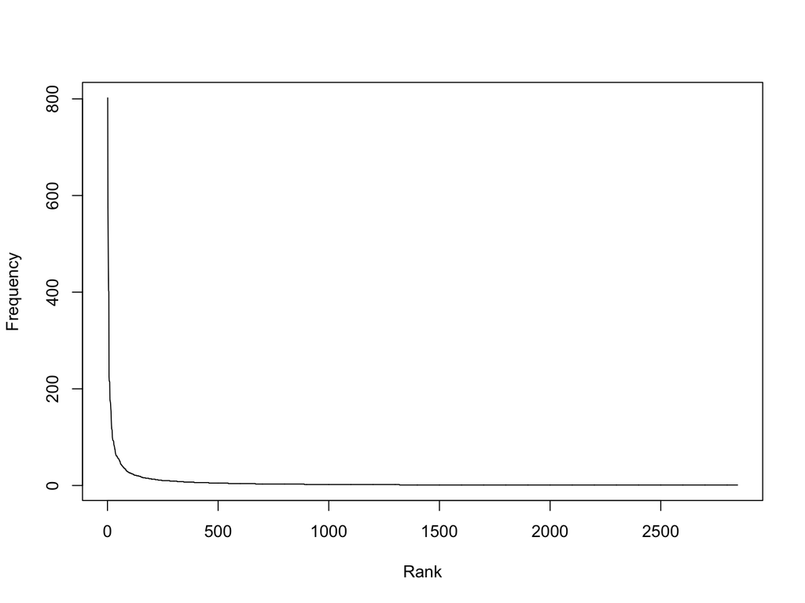

```r
nw = length(lala.wordtab.sorted)
plot(1:nw, as.numeric(lala.wordtab.sorted), type="l",
     xlab="Rank", ylab="Frequency")
```

A pretty drastic looking trend! It looks as if $\mathrm{Frequency} \propto (1/\mathrm{Rank})^a$ for some $a>0$

# Zipf’s law

This phenomenon, that frequency tends to be inversely proportional to a power of rank, is called **Zipf’s law**

```r
C = 500; a = 0.57
lala.wordtab.zipf = C*(1/1:nw)^a
cbind(lala.wordtab.sorted[1:8], lala.wordtab.zipf[1:8])
```

```
##           [,1]     [,2]
## the        802 500.0000
## a          575 336.8084
## mia        516 267.3073
## sebastian  450 226.8798
## and        404 199.7823
## to         401 180.0627
## you        225 164.9165
## her        216 152.8300
```

Not perfect, but not bad. We can also plot the original sorted word counts, and those estimated by our formula law on top

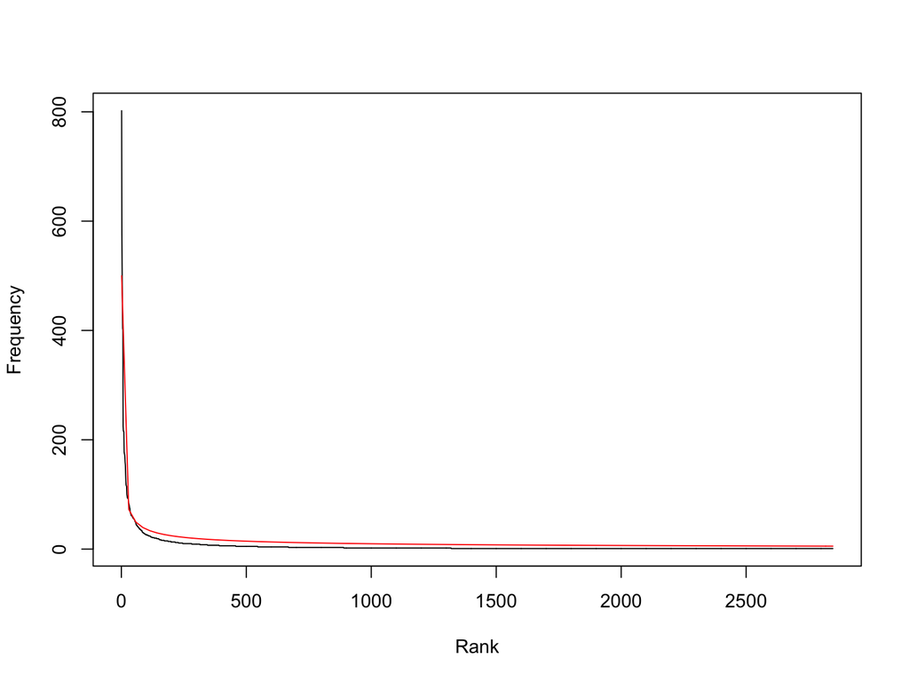

```r
plot(1:nw, as.numeric(lala.wordtab.sorted), type="l",
     xlab="Rank", ylab="Frequency")
curve(C*(1/x)^a, from=1, to=nw, col="red", add=TRUE)
```

We’ll learn about plotting tools in detail a bit later

# Summary

- Strings are, simply put, sequences of characters bound together
- Text data occurs frequently “in the wild”, so you should learn how to deal with it!
- `nchar()`, `substr()`: functions for substring extractions and replacements
- `strsplit()`, `paste()`: functions for splitting and combining strings
- Reconstitution: take lines of text, combine into one long string, then split to get the words
- `table()`: function to get word counts, useful way of summarizing text data
- Zipf’s law: word frequency tends to be inversely proportional to (a power of) rank